# Health and Economic Consequences of Storms Across the US

Tuesday, November 18, 2014

## Reproducible Research - Assessment 2

## Synopsis

The basic goal of this project is to explore the NOAA Storm Database to answer the following questions: 1. Across the United States, which types of events (as indicated in the EVTYPE variable) are most harmful with respect to population health? 2. Across the United States, which types of events have the greatest economic consequences?

The data used for this project was downloaded from Storm Data [47Mb] https://d396qusza40orc.cloudfront.net/repdata%2Fdata%2FStormData.csv.bz2. The related documentation was downloaded from the “National Weather Service Storm Data Documentation” https://d396qusza40orc.cloudfront.net/repdata%2Fpeer2_doc%2Fpd01016005curr.pdf and “National Climatic Data Center Storm Events FAQ” https://d396qusza40orc.cloudfront.net/repdata%2Fpeer2_doc%2FNCDC%20Storm%20Events-FAQ%20Page.pdf

## Data Processing

### Population Health Data Processing

First we use the `aggregate` function to get the total number of fatalities by event type. Then we order the results in the descending order of fatalities.

```r
library (dplyr)
library (RCurl)
library (R.utils)
```

```r
# download file from URL
if (!file.exists("./repdata_data_StormData.csv.bz2")) {
    download.file("http://d396qusza40orc.cloudfront.net/repdata%2Fdata%2FStormData.csv.bz2",
              "repdata_data_StormData.csv.bz2")
}
# unzip file
if (!file.exists("./repdata_data_StormData.csv")) {
    bunzip2("repdata_data_StormData.csv.bz2", "repdata_data_StormData.csv", remove = FALSE)
}
#Read the CSV file
dfStormData <- read.csv(file = "repdata_data_StormData.csv")
```

```r
#Get the total number of fatalities by event type
populationHealth <- aggregate (FATALITIES ~ EVTYPE, sum, data=dfStormData)

#Order the fatalities in descending order
populationHealthOrdered = populationHealth[order(-populationHealth$FATALITIES), ]
```

```r
#Get the total number of i bynjuries event type
populationHealthInjuries <- aggregate (INJURIES ~ EVTYPE, sum, data=dfStormData)

#Order the fatalities in descending order
populationHealthInjuriesOrdered = populationHealthInjuries[order(-populationHealthInjuries$INJURIES), ]
```

### Property Damage Data Processing

The values of the property damage are in the form of exponents. The `PROPEXP` column contains the alphabtical representation of the value by which the `PROPDMG` column should be multiplied to get the numerical value of the property damage. A new column that represents the total property damage was added to the data frame. The `r` code for this data processing is shown below.

```r
#Property Data
unique(dfStormData$PROPDMGEXP)
```

```
##  [1] K M   B m + 0 5 6 ? 4 2 3 h 7 H - 1 8
## Levels:  - ? + 0 1 2 3 4 5 6 7 8 B h H K m M
```

```r
#Replace the alphabetical exponential values by numeric values
dfStormData$PROPEXP[dfStormData$PROPDMGEXP == "K"] <- 1000
dfStormData$PROPEXP[dfStormData$PROPDMGEXP == "M"] <- 1e+06
dfStormData$PROPEXP[dfStormData$PROPDMGEXP == ""] <- 1
dfStormData$PROPEXP[dfStormData$PROPDMGEXP == "B"] <- 1e+09
dfStormData$PROPEXP[dfStormData$PROPDMGEXP == "m"] <- 1e+06
dfStormData$PROPEXP[dfStormData$PROPDMGEXP == "0"] <- 1
dfStormData$PROPEXP[dfStormData$PROPDMGEXP == "5"] <- 1e+05
dfStormData$PROPEXP[dfStormData$PROPDMGEXP == "6"] <- 1e+06
dfStormData$PROPEXP[dfStormData$PROPDMGEXP == "4"] <- 10000
dfStormData$PROPEXP[dfStormData$PROPDMGEXP == "2"] <- 100
dfStormData$PROPEXP[dfStormData$PROPDMGEXP == "3"] <- 1000
dfStormData$PROPEXP[dfStormData$PROPDMGEXP == "h"] <- 100
dfStormData$PROPEXP[dfStormData$PROPDMGEXP == "7"] <- 1e+07
dfStormData$PROPEXP[dfStormData$PROPDMGEXP == "H"] <- 100
dfStormData$PROPEXP[dfStormData$PROPDMGEXP == "1"] <- 10
dfStormData$PROPEXP[dfStormData$PROPDMGEXP == "8"] <- 1e+08
# give 0 to invalid exponent data, so they not count in
dfStormData$PROPEXP[dfStormData$PROPDMGEXP == "+"] <- 0
dfStormData$PROPEXP[dfStormData$PROPDMGEXP == "-"] <- 0
dfStormData$PROPEXP[dfStormData$PROPDMGEXP == "?"] <- 0

#Add a new column to store the property damage values
dfStormData$PROPDMGNUM <- dfStormData$PROPDMG * dfStormData$PROPEXP

#Order the results in the descending order of property damage.
propertyDamage <- aggregate (PROPDMGNUM ~ EVTYPE, sum, data=dfStormData)
propertyDamageOrdered = propertyDamage[order(-propertyDamage$PROPDMGNUM), ]
```

Similar processing was done to calculate the crop damage. The columns used in this case were `CROPDMG` and `CROPDMGEXP`. A new column that represents the total crop damage was also added to the data frame.

```r
#CROP data
unique(dfStormData$CROPDMGEXP)
```

```
## [1]   M K m B ? 0 k 2
## Levels:  ? 0 2 B k K m M
```

```r
#Replace the alphabetical exponential values by numeric values
dfStormData$CROPEXP[dfStormData$CROPDMGEXP == "M"] <- 1e+06
dfStormData$CROPEXP[dfStormData$CROPDMGEXP == "K"] <- 1000
dfStormData$CROPEXP[dfStormData$CROPDMGEXP == "m"] <- 1e+06
dfStormData$CROPEXP[dfStormData$CROPDMGEXP == "B"] <- 1e+09
dfStormData$CROPEXP[dfStormData$CROPDMGEXP == "0"] <- 1
dfStormData$CROPEXP[dfStormData$CROPDMGEXP == "k"] <- 1000
dfStormData$CROPEXP[dfStormData$CROPDMGEXP == "2"] <- 100
dfStormData$CROPEXP[dfStormData$CROPDMGEXP == ""] <- 1
# give 0 to invalid exponent data, so they not count in
dfStormData$CROPEXP[dfStormData$CROPDMGEXP == "?"] <- 0

#Add a new column to store the crop damage values
dfStormData$CROPDMGNUM <- dfStormData$CROPDMG * dfStormData$CROPEXP

#Order the results in the descending order of crop damage.
cropDamage <- aggregate (CROPDMGNUM ~ EVTYPE, sum, data=dfStormData)
cropDamageOrdered = cropDamage[order(-cropDamage$CROPDMGNUM), ]
```

## Results

We plot the top 10 event types that resulted in the most fatalities, property damage and crop damage below. Based on the plots, we conclude the following:

1. The weather events types that caused the most fatalities are: tornado, excessive heat, flash flood, heat and lightening.
2. The weather events that caused the most injuries are: tornado, TSTM wind, flood and excessive heat.
3. The weather events that caused the most property damage are: flood, typhoon, tornado and storm surge.
4. The weather events that caused the most crop damage are: draught, flood, river flood and ice storm.

[figure not shown]

```r
## Results
par(mfrow = c(1,2), mar = c(12, 4, 3, 2), mgp = c(3, 1, 0), cex = 0.8)
barplot(head (populationHealthOrdered$FATALITIES, 10), las= 3, names.arg = head (populationHealthOrdered$EVTYPE, 10), ylab = "Number of Fatalities", main = "Fatalities by Event Type", col = "red")
barplot(head (populationHealthInjuriesOrdered$INJURIES, 10), las= 3, names.arg = head (populationHealthInjuriesOrdered$EVTYPE, 10), main = "Fatalities by Event Type", ylab = "Number of Injuries", col = "red")
```

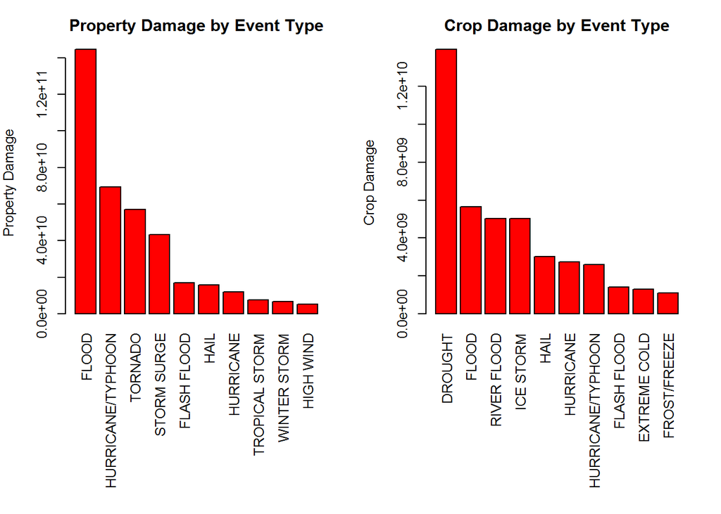

```r
par(mfrow = c(1,2), mar = c(12, 4, 3, 2), mgp = c(3, 1, 0), cex = 0.8)
barplot(head (propertyDamageOrdered$PROPDMGNUM, 10), las= 3, names.arg = head (propertyDamageOrdered$EVTYPE, 10), main = "Property Damage by Event Type", ylab = "Property Damage", col = "red")
barplot(head (cropDamageOrdered$CROPDMGNUM, 10), las= 3, names.arg = head (cropDamageOrdered$EVTYPE, 10), main = "Crop Damage by Event Type", ylab = "Crop Damage", col = "red")
```